# Statistical Rethinking

Chapter 3 notes

Dan Killian

2/13/2022

Consider Bayes Theorem in the context of medical testing. Let there be a medical test that is either positive (+) or negative (-).

$$Pr(infected|+)=\frac{Pr(+|infected)Pr(infected)}{Pr(+)}$$

Given that we are dealing with a binary outcome, we can rewrite the denominator as the weighted average of positive and negative tests. We’ll write this in terms of probabilities.

$$Pr(infected|+)=\frac{Pr(+|infected)Pr(infected)}{Pr(+|infected)Pr(infected) + Pr(+|uninfected)Pr(uninfected)}$$

Let’s take the following:

```r
Pr_Positive_Infected <- 0.95
Pr_Positive_NotInfected <- 0.01
Pr_Infected <- 0.001

Pr_Positive <- Pr_Positive_Infected * Pr_Infected +
  Pr_Positive_NotInfected * ( 1 - Pr_Infected )

( Pr_Infected_Positive <- Pr_Positive_Infected*Pr_Infected / Pr_Positive )
```

```
## [1] 0.0868
```

That is all.

## 3.1 Sampling from a grid-approximate posterior

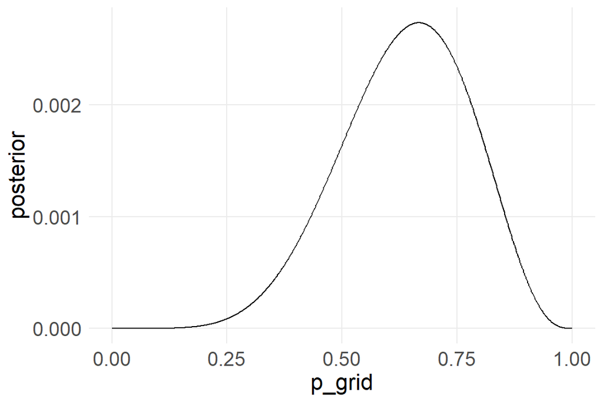

```r
p_grid <- seq( from=0 , to=1 , length.out=1000 )
prob_p <- rep( 1 , 1000 )
prob_data <- dbinom( 6 , size=9 , prob=p_grid )
posterior <- prob_data * prob_p
posterior <- posterior / sum(posterior)

ggplot(data.frame(p_grid, posterior), aes(p_grid, posterior)) +
  geom_line()
```

Let’s do the same thing with samples from the posterior.

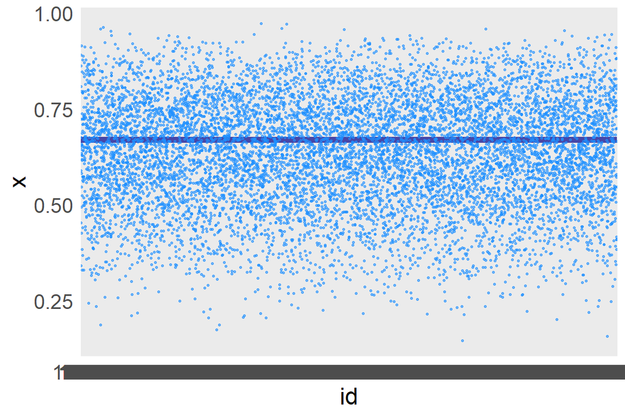

```r
## R code 3.3
samples <- data.frame(x=sample( p_grid , prob=posterior , size=1e4 , replace=TRUE )) %>%
  rownames_to_column("id")

## R code 3.4

ggplot(samples, aes(id, x)) +
  geom_hline(yintercept=.67, color="darkblue", size=2, alpha=.7) +
  geom_point(size=.6, color="dodgerblue", alpha=.6) +
  theme(axis.ticks.x=element_blank())
```

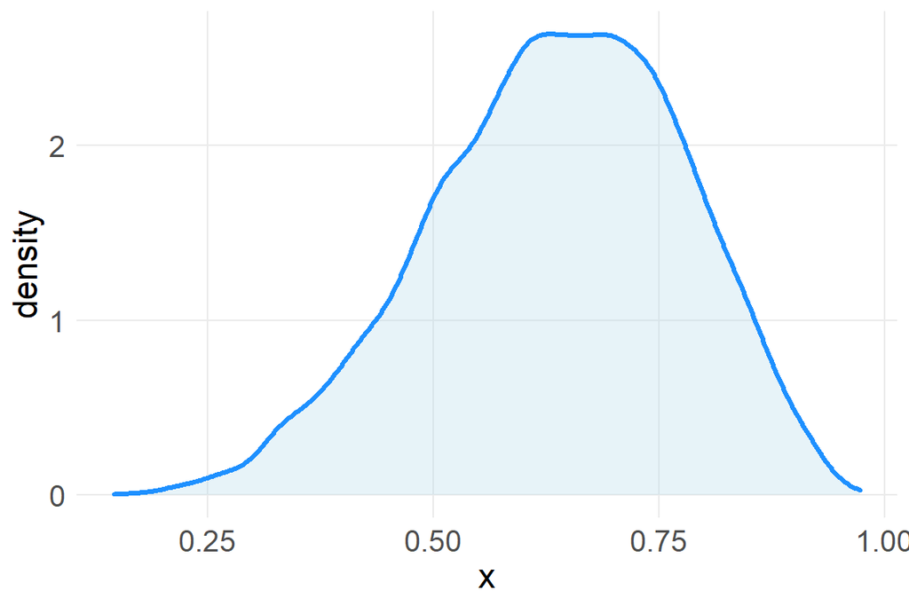

```r
ggplot(samples, aes(x)) +
geom_density(color="dodgerblue", size=1.2, fill="lightblue", alpha=.3)
```

# 3.2 Sampling to summarize

Why would we want to draw samples from the posterior distribution? We do this to conduct statistical inference. These could follow three main themes: (1) intervals of defined boundaries, and (2) questions about intervals of defined probability mass, and (3) questions about point estimates.

### 3.2.1 Intervals of defined boundaries

What’s the probability that the proportion of water on Earth is less than 50%?

Recall that the posterior is a probability distribution that sums to 1, so we can simply add up the posterior values along the grid that are less than 50%.

```r
# add up posterior probability where p < 0.5
sum( posterior[ p_grid < 0.5 ] )
```

```
## [1] 0.172
```

More intuitive is to work with a sample of parameter estimates, which we interpret as representing the true probability distribution. So we simply look at what proportion of estimates are less than 50%, from the entire distribution of parameter estimates.

```r
## R code 3.7
sum( samples < 0.5 ) / 1e4
```

```
## [1] 0.173
```

What proportion of estimates are between 50 and 75 percent?

```r
## R code 3.8
sum( samples > 0.5 & samples < 0.75 ) / 1e4
```

```
## [1] 0.604
```

# 3.2.2 Intervals of defined mass

Let’s look at the range and endpoints defined by the probability mass, rather than a pre-defined interval of unknown mass.

What are the boundaries of the lower 80% of the posterior distribution?

```r
quantile( samples$x , 0.8 )
```

```
##  80%
## 0.76
```

What interval defines the middle 80% of the posterior probability mass?

```r
## R code 3.10
quantile( samples[,2] , c( 0.1 , 0.9 ) )
```

```
##   10%   90%
## 0.446 0.813
```

These intervals assign equal mass to each side, which doesn’t work as well for assymetric distributions.

```r
set.seed(43)
p_grid <- seq( from=0 , to=1 , length.out=1000 )
prior <- rep(1,1000)
likelihood <- dbinom( 3 , size=3 , prob=p_grid )
posterior <- likelihood * prior
posterior <- posterior / sum(posterior)
samples <- data.frame(x = sample( p_grid , size=1e4 , replace=TRUE , prob=posterior ))

PI( samples , prob=0.5 )
```

[output not shown]

```r
## R code 3.13
HPDI( samples , prob=0.5 )
```

```
##  |0.5  0.5|
## 0.843 1.000
```

```r
## R code 3.14
p_grid[ which.max(posterior) ]
```

```
## [1] 1
```

```r
## R code 3.15
chainmode( samples , adj=0.01 )
```

```
## Error in density.default(chain, ...): argument 'x' must be numeric
```

```r
## R code 3.16
mean( samples )
```

```
## [1] NA
```

```r
median( samples )
```

```
## Error in median.default(samples): need numeric data
```

```r
## R code 3.17
sum( posterior*abs( 0.5 - p_grid ) )
```

```
## [1] 0.313
```

```r
## R code 3.18
loss <- sapply( p_grid , function(d) sum( posterior*abs( d - p_grid ) ) )
```

```r
## R code 3.19
p_grid[ which.min(loss) ]
```

```
## [1] 0.841
```

```r
## R code 3.20
dbinom( 0:2 , size=2 , prob=0.7 )
```

```
## [1] 0.09 0.42 0.49
```

```r
## R code 3.21
rbinom( 1 , size=2 , prob=0.7 )
```

```
## [1] 1
```

```r
## R code 3.22
rbinom( 10 , size=2 , prob=0.7 )
```

```
##  [1] 2 1 2 2 0 2 1 1 1 1
```

```r
## R code 3.23
dummy_w <- rbinom( 1e5 , size=2 , prob=0.7 )
table(dummy_w)/1e5
```

```
## dummy_w
##      0      1      2
## 0.0885 0.4185 0.4930
```

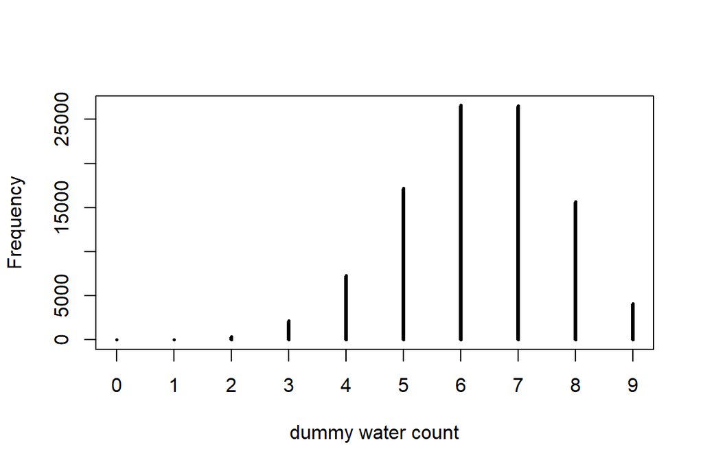

```r
## R code 3.24
dummy_w <- rbinom( 1e5 , size=9 , prob=0.7 )
simplehist( dummy_w , xlab="dummy water count" )
```

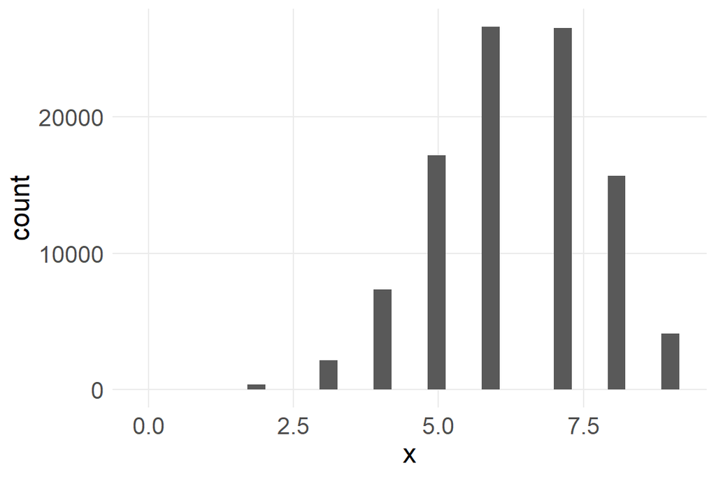

```r
ggplot(data.frame(x=dummy_w), aes(x)) +
  geom_histogram()
```

```r
## R code 3.25
w <- rbinom( 1e4 , size=9 , prob=0.6 )

## R code 3.26
w <- rbinom( 1e4 , size=9 , prob=samples )
```

```
## Error in rbinom(10000, size = 9, prob = samples): invalid arguments
```

```r
## R code 3.27
p_grid <- seq( from=0 , to=1 , length.out=1000 )
prior <- rep( 1 , 1000 )
likelihood <- dbinom( 6 , size=9 , prob=p_grid )
posterior <- likelihood * prior
posterior <- posterior / sum(posterior)
set.seed(100)
samples <- sample( p_grid , prob=posterior , size=1e4 , replace=TRUE )
```

## R code 3.30

sum(birth1) + sum(birth2)

[output not shown]